# 历史回测平台backtrader的快速上手

pandas backtrader

Quantitative Investment

Publish Date: 2021-12-17

Update Date: 2024-01-23

Word Count: 610

Read Times: 2 Min

## 历史回测平台backtrader的快速上手

[backtrader](https://www.backtrader.com/)是目前全球范围内基于Python功能最完善的量化回测平台之一，有比较大的社区环境，所以很容易找到帮助。框架也很容易理解，对于一个回测需求，使用backtrader主要包含以下7个步骤。

- 创立一个Cerebro，Cerebro是西班牙语大脑的意思，这一步就相当于创立一个大脑，后续把数据和策略放进大脑以后我们就可以得到分析结果。
- 添加Data Feeds，这里是数据的输入，原始数据需要先做一些处理得到Cerebro能够读取的格式，Data Feeds可以添加pandas（PandasData）的DataFrame数据或者CSV（BackTraderCSVData）原始数据。
- 添加策略
- 添加其他内容，比如添加writer（addwriter），分析（addanalyzer）或者观察者（addobserver），这一步骤不是必须的。
- 修改Broker信息，比如佣金，杠杆率等，这一步骤也不是必须的
- 运行策略
- 作图画出结果，以便后续修改策略和其他内容再进一步回测。

以下通过AAPL的历史数据来记录backtrader的快速上手流程。

### 导入所需的各种Python包

```python
from __future__ import (absolute_import, division, print_function,
                        unicode_literals)
import backtrader as bt
import pandas as pd
import datetime
```

### 创建一个Cerebro

```python
cerebro = bt.Cerebro()
```

### 添加数据 data feed

这里的数据通过[yfinance](https://pypi.org/project/yfinance/)包从雅虎财经上获取，如何获取可以参考[这里](https://www.wenvenn.com/20211215/shi-yong-python-bao-yfinance-du-qu-ya-hu-cai-jing-shang-de-gu-piao-shu-ju/)。以下通过pandas读取AAPL的历史数据。

```python
aapl = pd.read_csv('AAPL_20211216.csv')
aapl.head()
```

|  | Date | Open | High | Low | Close | Volume |
| --- | --- | --- | --- | --- | --- | --- |
| 0 | 1980-12-12 | 0.100453 | 0.100890 | 0.100453 | 0.100453 | 469033600 |
| 1 | 1980-12-15 | 0.095649 | 0.095649 | 0.095213 | 0.095213 | 175884800 |
| 2 | 1980-12-16 | 0.088661 | 0.088661 | 0.088224 | 0.088224 | 105728000 |
| 3 | 1980-12-17 | 0.090408 | 0.090845 | 0.090408 | 0.090408 | 86441600 |
| 4 | 1980-12-18 | 0.093029 | 0.093466 | 0.093029 | 0.093029 | 73449600 |

pandas读取上来的数据需要做一些处理，比如时间格式和整个dataframe的index设置。这里采用2009年1月1日开始到现在的天级历史数据作为data feed输入。

```python
aapl['datetime'] = pd.to_datetime(aapl['Date'])
aapl.set_index('datetime', inplace=True)

aapl_daily = bt.feeds.PandasData(dataname = aapl,
                                fromdate = datetime.datetime(2009,1,1),
                                todate = datetime.datetime(2021,12,15))
```

添加Data Feed到Cerebro。

```python
cerebro.adddata(aapl_daily)
```

### 添加策略

这里添加backtrader自带的默认空策略，仅用于展示功能。

```python
cerebro.addstrategy(bt.Strategy)
```

### 运行回测

```python
cerebro.run()
```

### 画出结果图

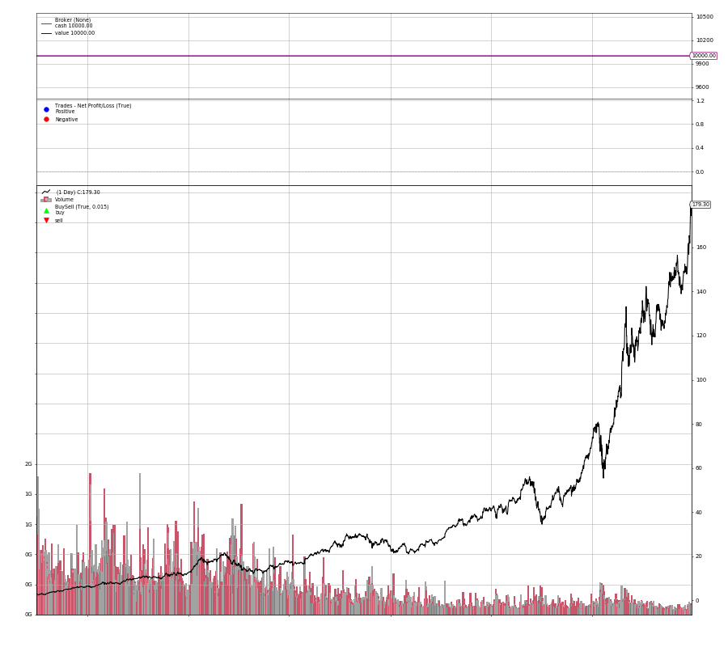

```python
cerebro.plot(width=30, heigth=20)
```

*Author:* wenvenn

*Link:* https://www.wenvenn.com/20211217/li-shi-hui-ce-ping-tai-backtrader-de-kuai-su-shang-shou/

*Reprint policy:* All articles in this blog are used except for special statements [CC BY 4.0](https://creativecommons.org/licenses/by/4.0/deed.zh) reprint policy. If reproduced, please indicate source wenvenn !

pandas backtrader

[figure not shown]

pandas backtrader

[figure not shown]